# IODS course project

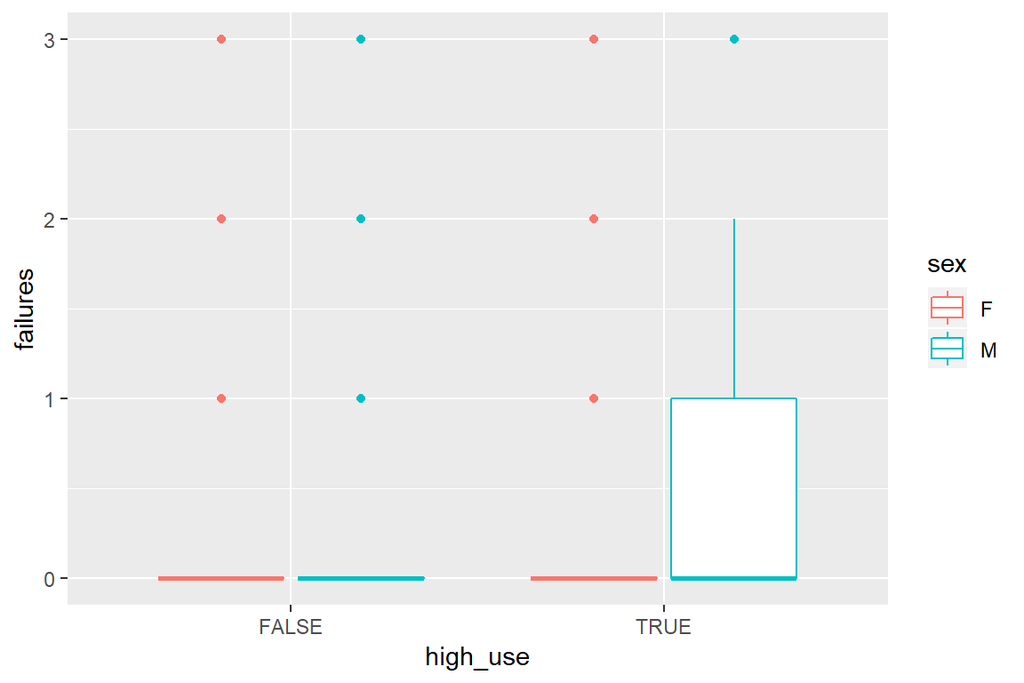

```r
g3 <- ggplot(alc1, aes(x = high_use, y = failures, col = sex))
g3 + geom_boxplot()
```

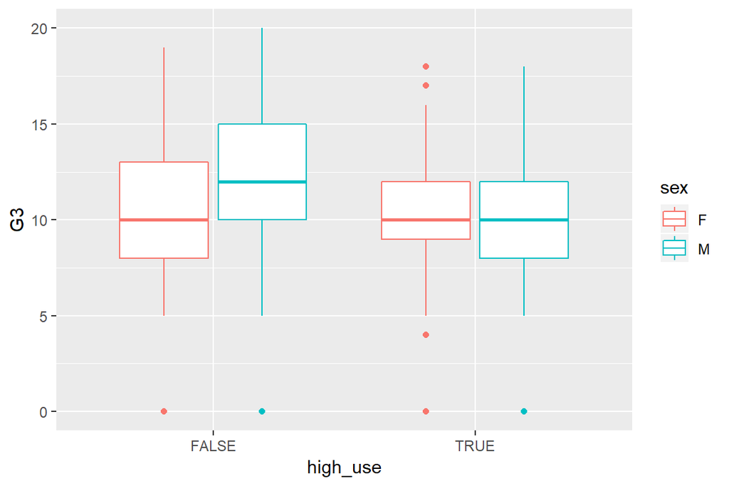

```r
g4 <- ggplot(alc1, aes(x = high_use, y = G3, col = sex))
g4 + geom_boxplot()
```

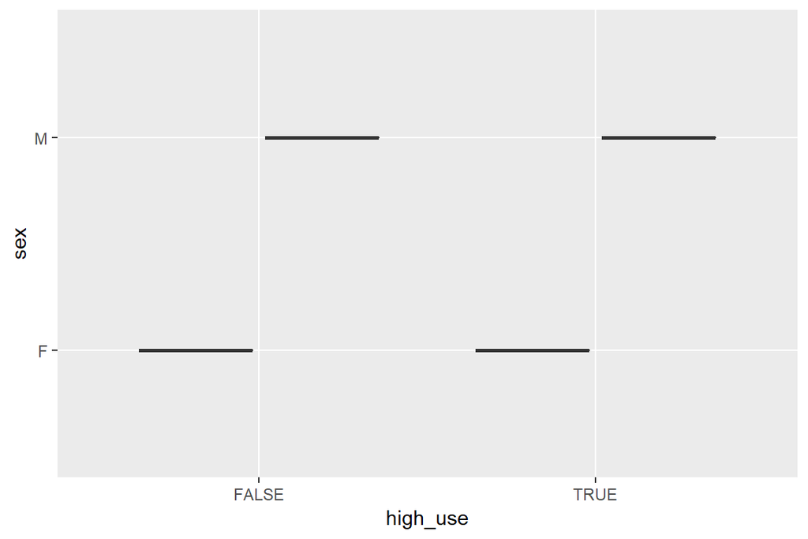

```r
g5 <- ggplot(alc1, aes(x = high_use, y = sex))
g5 + geom_boxplot()
```

Exploring the relationship between the chosen variables (sex,age,failures and G3) and high alcohol consumption

```r
m <- glm(high_use ~ failures + age + sex + G3, data = alc1, family = "binomial")
summary(m)
```

```
##
## Call:
## glm(formula = high_use ~ failures + age + sex + G3, family = "binomial",
##     data = alc1)
##
## Deviance Residuals:
##     Min       1Q   Median       3Q      Max
## -1.5699  -0.8458  -0.6670   1.2114   1.9480
##
## Coefficients:
##              Estimate Std. Error z value Pr(>|z|)
## (Intercept) -4.335970   1.762640  -2.460 0.013896 *
## failures     0.377124   0.165090   2.284 0.022351 *
## age          0.169872   0.101183   1.679 0.093178 .
## sexM         0.864639   0.237560   3.640 0.000273 ***
## G3           0.005294   0.027578   0.192 0.847762
## ---
## Signif. codes:  0 '***' 0.001 '**' 0.01 '*' 0.05 '.' 0.1 ' ' 1
##
## (Dispersion parameter for binomial family taken to be 1)
##
##     Null deviance: 462.21  on 381  degrees of freedom
## Residual deviance: 437.09  on 377  degrees of freedom
## AIC: 447.09
##
## Number of Fisher Scoring iterations: 4
```

based on the P-value I made the following conclusions: SexM has a P-value of 0.0003, and is therefore highly likely related to high alcohol consumption. Failures (P=0.022) is likely to have a relation with hihg alcohol consumption, due to it’s realtively low P-value. Age might be related to high alcohol consumption, but since the P-value isn’t that low it might be misleading. Grades do based on this, most likely not have a relation to high alcohol consumption. As i guessed in my hypothesis sex does matter, and males are more likely to consume more alcohol, failures have a realtion to high alcohol consumption as I guessed and age doesn’t matter as much asI guessed.

calculation odds ratios and confidence intervals

```r
OR <- coef(m) %>% exp
CI <- confint(m) %>% exp
cbind(OR, CI)
```

```
##                     OR        2.5 %    97.5 %
## (Intercept) 0.01308917 0.0003891024 0.3967964
## failures    1.45808496 1.0553798524 2.0249511
## age         1.18515318 0.9734594833 1.4487296
## sexM        2.37414821 1.4968479824 3.8050191
## G3          1.00530824 0.9528307205 1.0619595
```

The odds ratio describes the same things as the summary’s p-value described, i.e. that sex has a high correlation with high alcohol usage, failures has a correlation (not as strong), age might have a correlation with alcohol consumption, although this is uncertain and that grades does not correlatewith high alcohol consumption. I can tell this by looking at the odds ratio and the confidence interval. The higher they are, the more likely there is a relation between the two factors.If the OR is >1 there is likely a relation between the factors. According to this grades might have a correlation, but it’s lower than the rest so I concluded that it doesn’t affect much.

exploring the predicting powers of my model

```r
m <- glm(high_use ~ failures + age + sex + G3, data = alc1, family = "binomial")
probabilities <- predict(m, type = "response")
alc1 <- mutate(alc1, probability = probabilities)
alc1 <- mutate(alc1, prediction = probability > 0.5)
table(high_use = alc1$high_use, prediction = alc1$prediction)
```

```
##         prediction
## high_use FALSE TRUE
##    FALSE   259   11
##    TRUE     98   14
```

the cross tabulation describes how many of the predications were right, and how many were wrong. In the top left corner are true negatives (predicted as not high alcohol consumers and ther weren’t), in the bottom right corner is true positives (predicted as trueand they were true), in the top right is false positives (predicted as true but were false) and in the bottom left is false negatives (predicted as false but were true). From the tabulation you can see that 98 predictions were false negatives, that is almost 26% of the people in the data. Only about 3% were predicted as false positives, which is not too bad. In general the predictions are not that good, which are seen from these numbers and from the training error seen below.

```r
loss_func <- function(class, prob) {
  n_wrong <- abs(class - prob) > 0.5
  mean(n_wrong)
}
loss_func(class = alc1$high_use, prob = alc1$probability)
```

```
## [1] 0.2853403
```